# [es] RASTER I (o cómo usar las armas para la ciencia)

Rodrigo J. Alonso

2022-08-17

## **Introducción**

Podríamos pensar que los satétiles fueron creados con objetivos científicos, como explorar remotamente otros planetas, nuestra galaxia o el universo, o quizás podríamos pensar que son piezas claves en las telecomunicaciones y que, por lo tanto, fueron pensados para tal fin. Sin duda alguna hoy en día estas máquinas, que orbitan la tierra de muchas formas, nos brindan toneladas de información diaria sobre inimaginables cosas ([temperaturas, humedad](https://www.argentina.gob.ar/ciencia/conae/misiones-espaciales/sac-c/introduccion), [salinidad de los océanos](https://elpais.com/sociedad/2011/06/10/actualidad/1307656810_850215.html), [emisión de gases de efecto invernadero](https://www.britespace.eu/), tipos de [coberturas de la tierra](https://landsat.gsfc.nasa.gov/satellites/landsat-9/), [distancias, formas, composición de estrellas, planetas, galaxias, agujeros negros](https://webb.nasa.gov/) y un gigante etc.). Sin embargo, estos nos fueron sus orígenes. Estas maravillosas herramientas, como tantas otras, fueron creadas para la guerra. Los satélites modernos tienen su origen en la posguerra de la II Guerra Mundial, en el período (mal llamado) “Guerra Fría”. Fueron ([y lo siguen siendo](https://www.france24.com/es/minuto-a-minuto/20220309-c%C3%B3mo-las-im%C3%A1genes-satelitales-privadas-est%C3%A1n-dando-forma-al-conflicto-ucraniano)) aparatos diseñados para controlar al enemigo (movimientos, posiciones, recursos, etc.). Como efecto colateral de este desarrollo surgieron todas las aplicaciones derivadas que ya mencionamos.

No pretendemos angustiar a nadie con estas líneas, ni debatir sobre la condición humana (¿o si?). Pero quizás podamos aprender a usar algunas de estas armas con fines *de otra humanidad* y dibujar [otras órbitas](https://www.youtube.com/watch?v=-DRG6vCD2ts).

## **¿Qué es un raster?**

La información satelital (también llamada de *sensores remotos*) suele encontrarse de dos formas posibles: como un conjunto de vectores de distintas dimensiones, es decir, en **formato vectorial**, o como una grilla/matriz, es decir, en **formato raster**. Sobre este último formato vamos a empezar a hablar hoy.

Actualmente hay muchos y distintos tipos de software para el tratamiento de información espacial, los cuales forman parte de los llamados “Sistemas de Información Geográfica”(GIS, en inglés). En los últimos años se ha ido migrando de la utilización de dichos programas a entornos de programación abiertos, como R, Phyton, Java, etc. En este breve instructivo utilizaremos el software [R](https://www.r-project.org/) dentro del entorno de [RStudio](https://www.rstudio.com/).

### **Creando un raster**

Como siempre y antes de comenzar con una nueva serie de comandos, vamos a borrar los elementos guardados en la memoria de R y limpiar el *environment*. Además, vamos a setear nuestro directorio de trabajo.

```r
rm(list=ls())
#setwd("E:/Rodrigo/transiciones y mapas")
```

Hay varios paquetes en R para trabajar con datos espaciales. Uno de los últimos y más completos es **terra** [(gracias Terra por tu sacrificio)](https://www.youtube.com/watch?v=WsMLNm-R7Co). Así que vamos a cargarlo.

```r
library(terra)
```

Como dijimos anteriormente, un raster no es ni más ni menos que una matriz o grilla. El tamaño de la matriz está dado por el número de filas **m** y de columnas **n**. Cada intersección entre una fila y una columna representa el valor **i<sub>mn</sub>**. Dicho valor puede ser numérico o categórico. Hagamos una matriz de 10 filas por 10 columnas, de forma tradicional:

```r
matriz <- c(1:100) #Creo un vector de valores de 1 a 100
dim(matriz) <- c(10,10) #Asignamos las dimensiones de la matriz, en este caso de 10 x 10
matriz
```

```
##       [,1] [,2] [,3] [,4] [,5] [,6] [,7] [,8] [,9] [,10]
##  [1,]    1   11   21   31   41   51   61   71   81    91
##  [2,]    2   12   22   32   42   52   62   72   82    92
##  [3,]    3   13   23   33   43   53   63   73   83    93
##  [4,]    4   14   24   34   44   54   64   74   84    94
##  [5,]    5   15   25   35   45   55   65   75   85    95
##  [6,]    6   16   26   36   46   56   66   76   86    96
##  [7,]    7   17   27   37   47   57   67   77   87    97
##  [8,]    8   18   28   38   48   58   68   78   88    98
##  [9,]    9   19   29   39   49   59   69   79   89    99
## [10,]   10   20   30   40   50   60   70   80   90   100
```

El objeto **matriz** es nuestra matriz, donde cada una de las 100 casillas toma valores del 1 al 100. Transformemos a esta matriz en un objeto tipo raster y veamos qué pinta tiene:

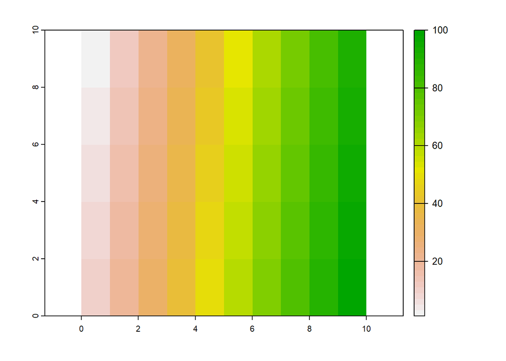

```r
e <- rast(matriz) #rast: convierte matrices a raster. También lee rasters y hace rasters automaticamente.
plot(e)
```

Lo que nos muestra este gráfico es nuestra matriz de 10 x 10, donde cada unas de las intersecciones toma un valor, señalizado en la escala de colores de la derecha (0: blanco, 100: verde). El objeto **e** ha dejado de ser una matriz, para transformarse en un objeto raster.

Otra forma de hacer un raster es utilizando directamente la función *rast*. Veamos cómo:

```r
E <- rast(ncol=10, nrow=10, xmin=0, xmax=10, ymin=0, ymax=10) #Es necesario expresar explicitamente los límites del raster (x,y min/max) para que sea igual a la matriz que hicimos antes.
```

El objeto **E** es creado directamente como un objeto raster. Sin embargo, no tiene valores, es simplemente un esqueleto. Vamos a asignarle valores:

```r
ncell(E) #Nos muestra el número de celdas.
```

```
## [1] 100
```

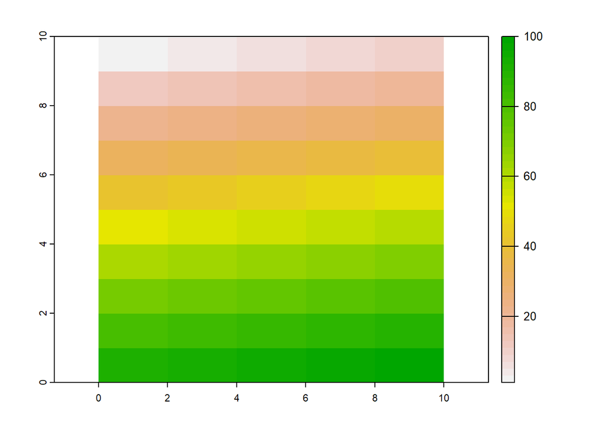

```r
values(E) <- 1:ncell(E) #Le decimos que adopte los valores desde  1 hasta el número de celdas de E
plot(E)
```

```r
crs(e) <- " +proj=tmerc +lat_0=-90 +lon_0=-60 +k=1 +x_0=5500000 +y_0=0 +ellps=WGS84 +towgs84=0,0,0,0,0,0,0 +units=m +no_defs"
#+proj: tipo de proyección, en este caso Trasversal Mercator.
#+lat_0: valor de latitud 0 u origen.
#+lon_0: valor de longitud 0 u origen.
#+k:factor de escalado del meridiano central
#+x_0: valor del falso este
#+y_0: valor del falso norte
#+ellps: elipsoide de referencia (¿qué forma de la tierra se encaja con tu proyección?)
#+towgs84: otros factores de escalado
#+units: unidad de medida
#+no_defs: sin otros seteos por default.
e
```

```
## class       : SpatRaster
## dimensions  : 10, 10, 1  (nrow, ncol, nlyr)
## resolution  : 1, 1  (x, y)
## extent      : 0, 10, 0, 10  (xmin, xmax, ymin, ymax)
## coord. ref. : +proj=tmerc +lat_0=-90 +lon_0=-60 +k=1 +x_0=5500000 +y_0=0 +ellps=WGS84 +towgs84=0,0,0,0,0,0,0 +units=m +no_defs
## source      : memory
## name        : lyr.1
## min value   :     1
## max value   :   100
```

En “coord. ref.” podemos ver los parámetros del CRS que le asignamos. Para poder proyectar una imagen y/o entender los parámetros de la cadena proj4 casi que tenemos que hacer un curso de cartografía. Veamos cómo es el comando para asignarle una proyección a nuestro raster utilizando los códigos EPSG. El código EPSG de **POSGAR 2007 faja 5** es 5347:

```r
crs(E)  <- "epsg:5347"
E
```

```
## class       : SpatRaster
## dimensions  : 10, 10, 1  (nrow, ncol, nlyr)
## resolution  : 1, 1  (x, y)
## extent      : 0, 10, 0, 10  (xmin, xmax, ymin, ymax)
## coord. ref. : POSGAR 2007 / Argentina 5 (EPSG:5347)
## source      : memory
## name        : lyr.1
## min value   :     1
## max value   :   100
```

**¡Me estas jodiennndoo!** diría un [famoso actor argentino](https://www.youtube.com/watch?v=hG5WfT0h3Ig). Con un simple código, establecimos el CRS. Al final, la industria petrolera no era taaan mala… (es broma, lo es). Supongamos que queremos proyectar un elemento espacial, en este caso un raster, con los valores de un CRS de otro elemento espacial. Podemos extraer los valores de un CRS y asignarselos a otro:

```r
crs(e)<-crs(E)
e
```

```
## class       : SpatRaster
## dimensions  : 10, 10, 1  (nrow, ncol, nlyr)
## resolution  : 1, 1  (x, y)
## extent      : 0, 10, 0, 10  (xmin, xmax, ymin, ymax)
## coord. ref. : POSGAR 2007 / Argentina 5 (EPSG:5347)
## source      : memory
## name        : lyr.1
## min value   :     1
## max value   :   100
```

### **Operaciones con rasters**

Ya vimos como crear un raster. También dijimos que un raster, en esencia, es una matriz con valores. Este concepto nos permite aplicarle álgebra matricial a nuestro objeto espacial. Veamos algunos ejemplos de operaciones básicas:

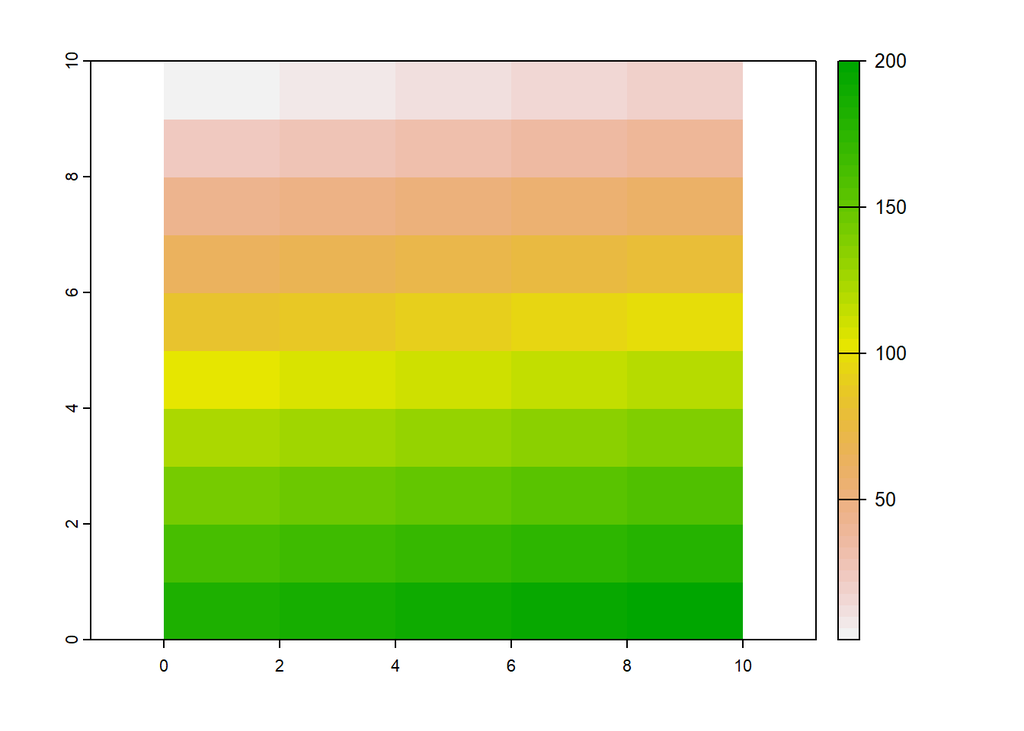

```r
F<-E*2 #multiplico los valores de la matriz x2
plot(F)
```

Podemos hacer sumas raster:

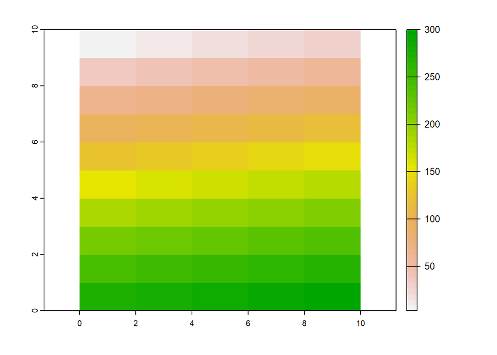

```r
H <- E+F #sumamos E + F
plot(H) #Notar cómo cambia la escalda de valores
```

Ahora el valor máximo del raster H es 300, que es la suma del máximo entre E y F. Esto nos muestra que la suma se hace al igual que la suma de matrices, posición a posición. Como la suma y la multiplicación son operaciones admitidas, también lo serán la resta y la división.

Otras funciones que resultan útiles a la hora de trabajar con objetos espaciales son las siguientes:

```r
class(E)
```

```
## [1] "SpatRaster"
## attr(,"package")
## [1] "terra"
```

Nos dice con qué tipo de objeto espacial estamos lidiando.

```r
cellSize(E)
```

```
## class       : SpatRaster
## dimensions  : 10, 10, 1  (nrow, ncol, nlyr)
## resolution  : 1, 1  (x, y)
## extent      : 0, 10, 0, 10  (xmin, xmax, ymin, ymax)
## coord. ref. : POSGAR 2007 / Argentina 5 (EPSG:5347)
## source      : memory
## name        :      area
## min value   : 0.5158278
## max value   : 0.5158328
```

Nos muestra el tamaño de la celda, en las unidades de la proyección que nosotros le dimos (m<sup>2</sup>).

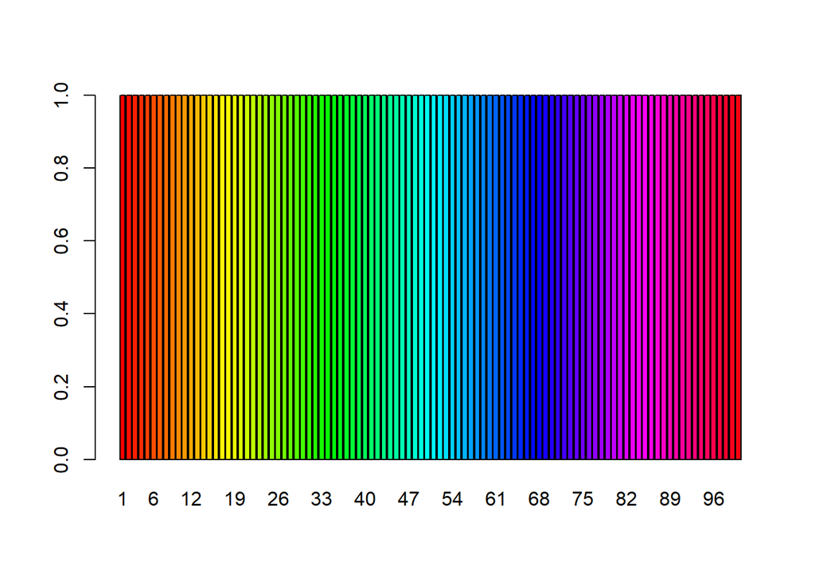

```r
barplot(E)
```

Nos arroja un gráfico de barras con la frecuencia de los valores presentes en el raster. Especialmente útil para contabilizar y caracterizar ambientes según tipos de cobertura. En este caso, como los valores no se repiten, siempre tienen la frencuencia uno. Hagamos un raster con valores aleatorios y veamos que nos muestra la función *barplot*.

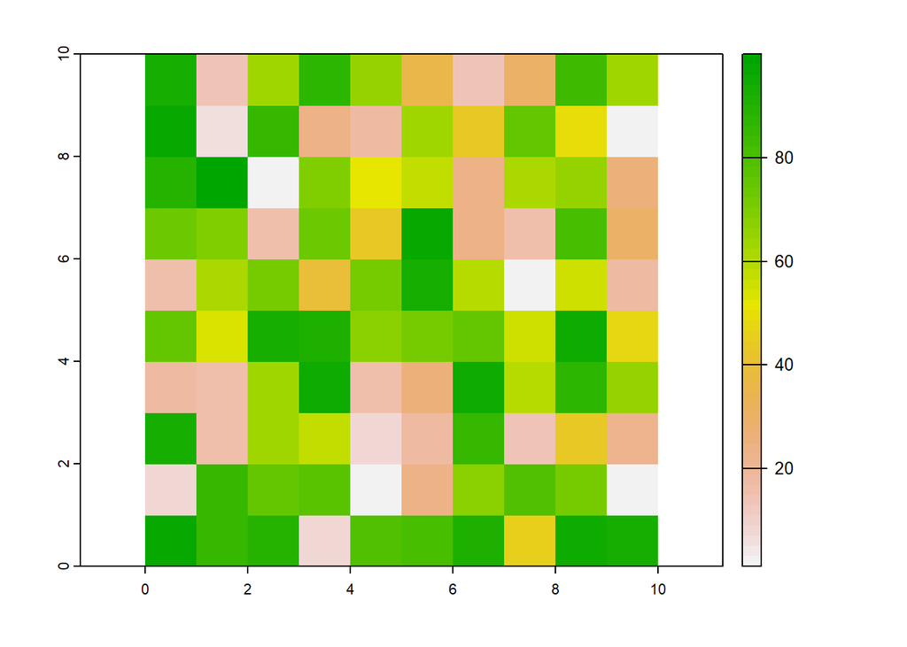

```r
I <- rast(ncol=10, nrow=10,xmin=0, xmax=10, ymin=0, ymax=10) #creo una raster
values(I) <- runif(100, min = 1, max = 100) #asignamos valores al azar entre 1 y 100
crs(I)  <- crs(E)
plot(I)
```

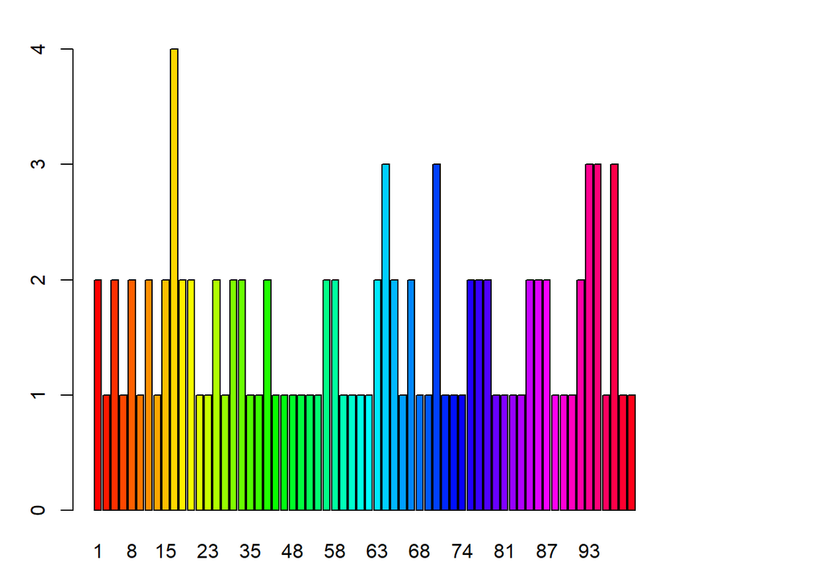

```r
barplot(I)
```

Ahora vemos que, por azar, hay varios valores repetidos en el raster.

Otra función interesante es la de capturar los valores de las coordenadas X e Y de nuestro raster (o de cualquier raster/objeto espacial) y guardarlas en un data frame o no:

```r
coordenadas <- crds(E, df=T, na.rm=TRUE) #Nos permite extraer las coordenadas de un raster y transformarlo en data frame (df=T) o no(df=F).
head(coordenadas)
```

```
##     x   y
## 1 0.5 9.5
## 2 1.5 9.5
## 3 2.5 9.5
## 4 3.5 9.5
## 5 4.5 9.5
## 6 5.5 9.5
```

Otra función muy útil es la que nos permite hacer una “pila” (stack, en inglés) de rasters. Cada raster será un capa (layer, en inglés). Esta función es especialmente útil cuando tenemos imágenes provenientes de distintas fuentes, como por ejemplo de sensores multiespectrales. Se puede asignar una imagen a un determinado color y crear imágenes compuestas. Pero eso también lo veremos más adelante.

```r
PILA <- c(E,F,H,I) #hago un "vector" de rasters
class(PILA)
```

```
## [1] "SpatRaster"
## attr(,"package")
## [1] "terra"
```

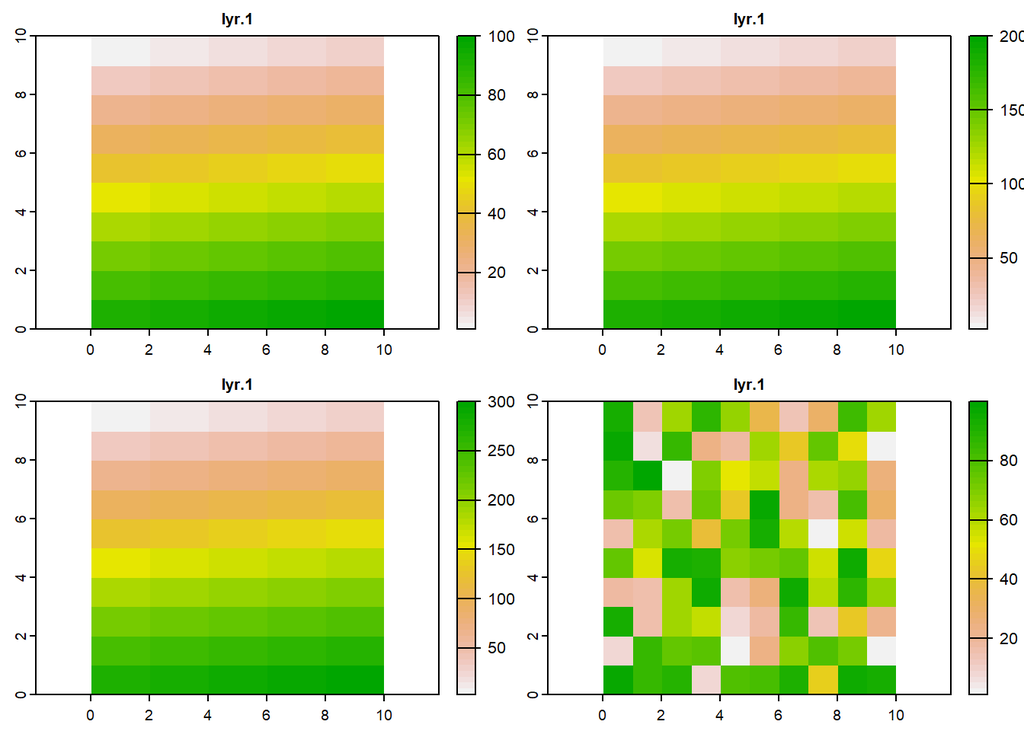

```r
plot(PILA)
```

Nuestro stack *PILA* sigue siendo un raster espacial.

Si necesitamos trabajar con alguna de las capas de la pila, podemos extraerla de manera individual:

```r
levels(PILA)
```

```
## [[1]]
## [1] ""
##
## [[2]]
## [1] ""
##
## [[3]]
## [1] ""
##
## [[4]]
## [1] ""
```

```r
J <- PILA[[4]]
```

Por úlitmo, una vez que hayamos terminado de trabajar con nuestros raster, podemos guardarlos como imágenes y dejarlas disponibles para un futuro trabajo en algún SIG:

```r
writeRaster(PILA,"Raster PILA.tif", overwrite=T) #Se guardará en nuestro directorio
getwd()
```

```
## [1] "C:/Users/mmfav/OneDrive/GitHub/soma quadrados/site_soma/proximos/blog/Post_Rodri"
```

## **Conclusión**

Ahora que sabemos un poquito más sobre cómo funcionan los rasters y qué podemos hacer con ellos, nos adentraremos en algunos de los tantos trabajos que podemos realizar usando objetos espaciales tipo raster, además de cómo visualizarlos y, si nos da el tiempo, obtener algunos datos y clasificar alguna imagen obtenida por sensores remotos multiespectrales. ¡Esperamos que haya sido útil! Nos leemos